# prey_capture_Gasteracantha

### Negative binomial model

```r
total_model_nb<-glmmTMB::glmmTMB(formula=total_preys ~ colour+Side+t_luxes+sqrt(web_area+10)+ check + (1|code) + (1|day/Time),family="nbinom2",REML=F,data=tmp_ind)
```

Test the fit of the model and zero inflation

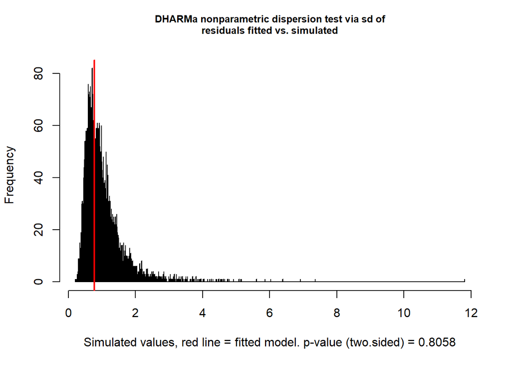

```
##
##  DHARMa nonparametric dispersion test via sd of residuals fitted vs.
##  simulated
##
## data:  simulationOutput
## dispersion = 0.7817, p-value = 0.8058
## alternative hypothesis: two.sided
```

```r
simulationOutput <- simulateResiduals(fittedModel = total_model_nb, n = 10000)
testDispersion(simulationOutput = simulationOutput, alternative ="two.sided")
```

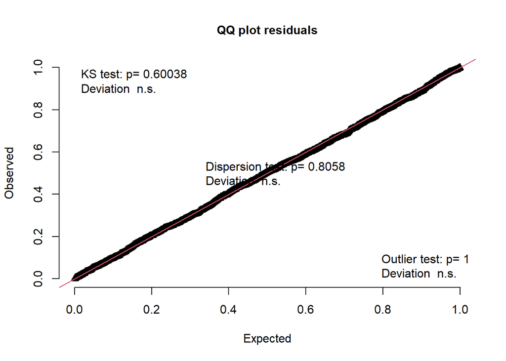

```
##
##  One-sample Kolmogorov-Smirnov test
##
## data:  simulationOutput$scaledResiduals
## D = 0.018165, p-value = 0.6004
## alternative hypothesis: two-sided
```

```r
testUniformity(simulationOutput = simulationOutput, alternative ="two.sided")
```

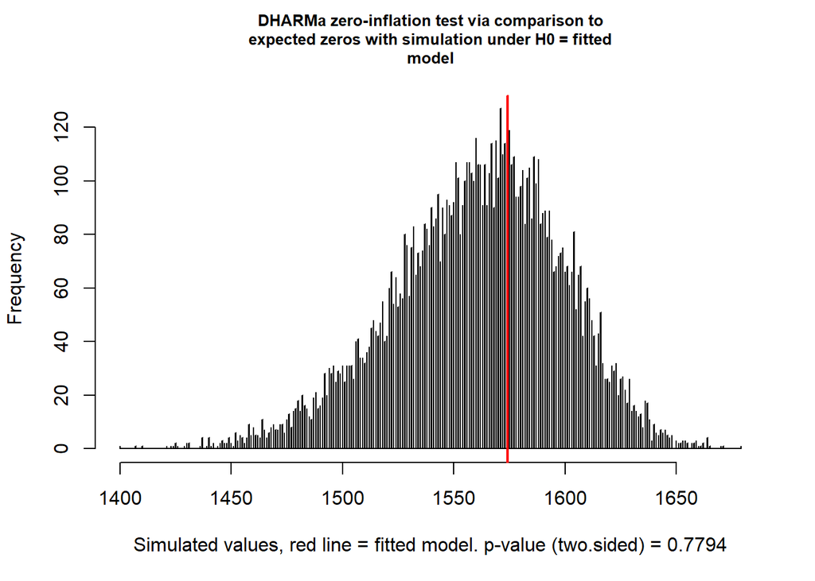

```
##
##  DHARMa zero-inflation test via comparison to expected zeros with
##  simulation under H0 = fitted model
##
## data:  simulationOutput
## ratioObsSim = 1.0086, p-value = 0.7794
## alternative hypothesis: two.sided
```

```r
testZeroInflation(simulationOutput = simulationOutput, alternative ="two.sided")
```

This model seems to be ok, let’s now check the significance of the predictors

```r
summary(total_model_nb)
```

```
##  Family: nbinom2  ( log )
## Formula:
## total_preys ~ colour + Side + t_luxes + sqrt(web_area + 10) +
##     check + (1 | code) + (1 | day/Time)
## Data: tmp_ind
##
##      AIC      BIC   logLik deviance df.resid
##   1625.4   1691.2   -800.7   1601.4     1766
##
## Random effects:
##
## Conditional model:
##  Groups   Name        Variance Std.Dev.
##  code     (Intercept) 0.2037   0.4513
##  Time:day (Intercept) 0.2596   0.5095
##  day      (Intercept) 0.2066   0.4546
## Number of obs: 1778, groups:  code, 129; Time:day, 23; day, 6
##
## Dispersion parameter for nbinom2 family (): 0.387
##
## Conditional model:
##                     Estimate Std. Error z value Pr(>|z|)
## (Intercept)         -3.10971    0.56554  -5.499 3.83e-08 ***
## colourblack         -0.17275    0.25510  -0.677 0.498281
## colouryellow        -0.12137    0.20569  -0.590 0.555169
## Sidedorsal           0.18636    0.15710   1.186 0.235528
## t_luxeslow           0.72967    0.22143   3.295 0.000983 ***
## sqrt(web_area + 10)  0.03035    0.02287   1.327 0.184353
## checkF               0.04343    0.23224   0.187 0.851646
## checkM              -0.35026    0.20964  -1.671 0.094773 .
## ---
## Signif. codes:  0 '***' 0.001 '**' 0.01 '*' 0.05 '.' 0.1 ' ' 1
```

```r
Anova(total_model_nb,type = 3)
```

```
## Analysis of Deviance Table (Type III Wald chisquare tests)
##
## Response: total_preys
##                       Chisq Df Pr(>Chisq)
## (Intercept)         30.2355  1  3.826e-08 ***
## colour               0.6111  2  0.7367028
## Side                 1.4072  1  0.2355283
## t_luxes             10.8590  1  0.0009831 ***
## sqrt(web_area + 10)  1.7622  1  0.1843529
## check                3.9086  2  0.1416656
## ---
## Signif. codes:  0 '***' 0.001 '**' 0.01 '*' 0.05 '.' 0.1 ' ' 1
```

To create the plot for the results, we have to predict the values under the model

```r
#Predict values to plot
tmp_ind$response_nb<-predict(total_model_nb,type="response")
```

**With this, we can create two plots, one per side in order to make easy to visualize the results**

###Plot dorsal

Create subset

```r
plot_dorsal <- tmp_ind %>% filter(Side=="dorsal")
plot_dorsal$colour<-relevel(as.factor(plot_dorsal$colour),"black")
```

Plot the results

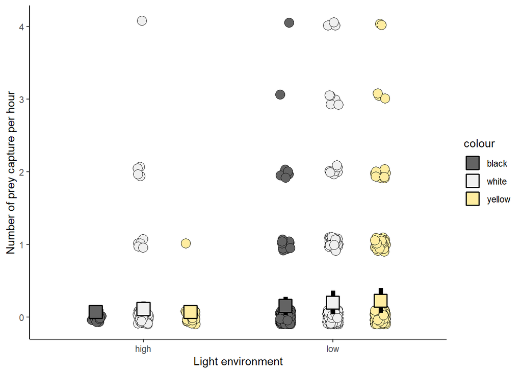

```r
#Colours
paleta2<-c("#636363","#f0f0f0","#ffeda0")
#plot
#pdf("dorsal.pdf",height=8,width=10)

ggplot(data = plot_dorsal,aes(x=t_luxes,y=response_nb, fill=colour))+
     geom_point(data = plot_dorsal,aes(x=t_luxes,y=total_preys, fill=colour),shape = 21,size=4, position = position_jitterdodge(jitter.width=0.15,jitter.height=0.1),alpha=1.0)+
       scale_fill_manual(values=paleta2)+
  #geom_violin(aes(fill=colour),alpha=0.3,size=0.4)+scale_color_manual(values=paleta2)+
     stat_summary(fun = mean,aes(color = colour,group=colour),fun.min = function(x) mean(x) - sd(x),fun.max = function(x) mean(x)+sd(x),geom = "pointrange", position = position_jitterdodge(jitter.width=0.01), linewidth = 2,size=1.5,shape=22, col="black")+
     theme_classic()+labs(x="Light environment",y="Number of prey capture per hour")
```

###Plot ventral

Create subset

```r
plot_ventral <- tmp_ind %>% filter(Side=="ventral")
plot_ventral$colour<-relevel(as.factor(plot_ventral$colour),"black")
```

Plot the results

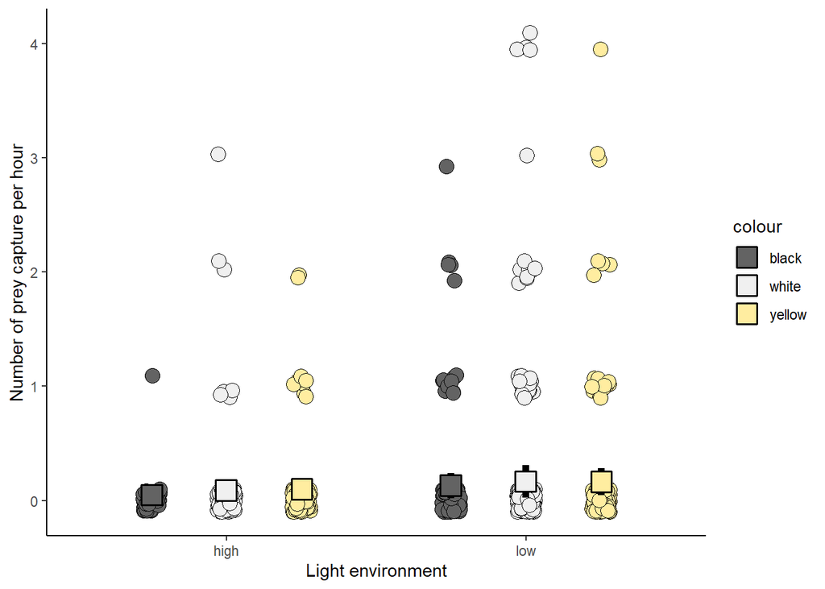

```r
#Colours
paleta2<-c("#636363","#f0f0f0","#ffeda0")
#plot
ggplot(data = plot_ventral,aes(x=t_luxes,y=response_nb, fill=colour))+
     geom_point(data = plot_ventral,aes(x=t_luxes,y=total_preys, fill=colour),shape = 21,size=4, position = position_jitterdodge(jitter.width=0.15,jitter.height=0.1),alpha=1.0)+
       scale_fill_manual(values=paleta2)+
  #geom_violin(aes(fill=colour),alpha=0.3,size=0.4)+scale_color_manual(values=paleta2)+
     stat_summary(fun = mean,aes(color = colour,group=colour),fun.min = function(x) mean(x) - sd(x),fun.max = function(x) mean(x)+sd(x),geom = "pointrange", position = position_jitterdodge(jitter.width=0.01), linewidth = 2,size=1.5,shape=22, col="black")+
     theme_classic()+labs(x="Light environment",y="Number of prey capture per hour")
```

###Plot by light condition

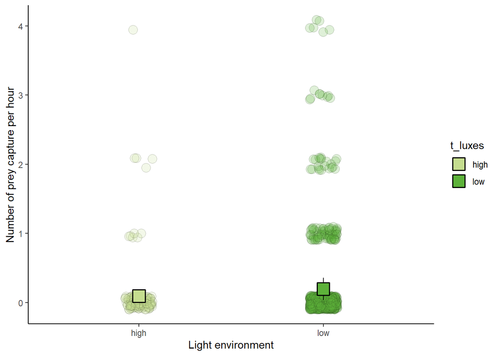

```r
#Colours
paleta2<-c("#c5dd8f","#5db23a")
#pdf("light_prey.pdf",height=8,width=10)
#plot
ggplot(data = plot_dorsal,aes(x=t_luxes,y=response_nb, fill=t_luxes))+
     geom_point(data = plot_dorsal,aes(x=t_luxes,y=total_preys, fill=t_luxes),shape = 21,size=4, position = position_jitterdodge(jitter.width=0.15,jitter.height=0.1),alpha=0.2)+
       scale_fill_manual(values=paleta2)+
     stat_summary(fun = mean,aes(color = t_luxes,group=t_luxes),fun.min = function(x) mean(x) - sd(x),fun.max = function(x) mean(x)+sd(x),geom = "pointrange", size=1.5, shape=22, col="black")+
     theme_classic()+labs(x="Light environment",y="Number of prey capture per hour")
```

### some supplementary plots

```r
tmp_ind %>% filter(total_preys>0) %>% drop_na(Preys_ID) %>% pull(Preys_ID) %>% table() %>% prop.table()
```

```
## .
##  coleoptera     diptera   hemiptera   homoptera hymenoptera lepidoptera
##  0.01775148  0.82840237  0.02958580  0.01183432  0.08875740  0.01775148
##  neuroptera
##  0.00591716
```

```r
preys<-tmp_ind %>% filter(total_preys>0) %>% drop_na(Preys_ID) %>% select(colour,Preys_ID,total_preys) %>% uncount(total_preys)

prop.table(table(preys$Preys_ID))*100
```

```
##
##  coleoptera     diptera   hemiptera   homoptera hymenoptera lepidoptera
##   1.5094340  86.4150943   2.2641509   0.7547170   7.1698113   1.5094340
##  neuroptera
##   0.3773585
```

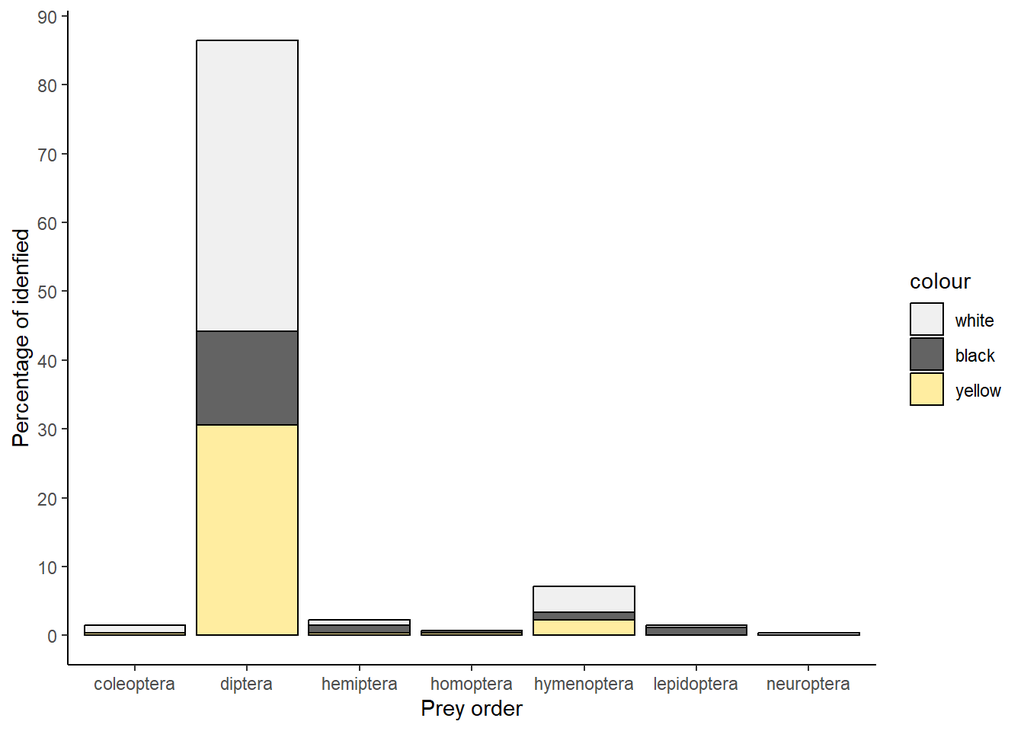

```r
paleta2<-c("#f0f0f0","#636363","#ffeda0")
preys %>% ggplot(aes(x=Preys_ID,fill=colour)) + geom_bar(aes(y = after_stat((count/sum(count))*100)),colour="black") + scale_fill_manual(values=paleta2)+theme_classic()+scale_y_continuous(breaks=seq(0,100,10))+labs(y="Percentage of idenfied",x="Prey order")
```